# Risk Factor Analysis

## Outcome Variable

**Outcome Variable:** pers_wasted624

## Predictor Variables

**Intervention Variable:** ever_sunderweight06

**Adjustment Set:**

- sex
- arm
- enstunt
- month
- brthmon
- vagbrth
- single
- W_gagebrth
- W_birthwt
- W_birthlen
- W_mage
- W_mhtcm
- W_meducyrs
- W_feducyrs
- W_parity
- delta_month
- delta_brthmon
- delta_vagbrth
- delta_single
- delta_W_gagebrth
- delta_W_birthwt
- delta_W_birthlen
- delta_W_mage
- delta_W_mhtcm
- delta_W_meducyrs
- delta_W_feducyrs
- delta_W_parity

## Stratifying Variables

The analysis was stratified on these variable(s):

- studyid
- country

## Data Summary

| studyid | country | ever_sunderweight06 | pers_wasted624 | n_cell | n |
| --- | --- | --- | --- | --- | --- |
| ki0047075b-MAL-ED | BANGLADESH | 0 | 0 | 212 | 239 |
| ki0047075b-MAL-ED | BANGLADESH | 0 | 1 | 15 | 239 |
| ki0047075b-MAL-ED | BANGLADESH | 1 | 0 | 9 | 239 |
| ki0047075b-MAL-ED | BANGLADESH | 1 | 1 | 3 | 239 |
| ki0047075b-MAL-ED | BRAZIL | 0 | 0 | 200 | 202 |
| ki0047075b-MAL-ED | BRAZIL | 0 | 1 | 2 | 202 |
| ki0047075b-MAL-ED | BRAZIL | 1 | 0 | 0 | 202 |
| ki0047075b-MAL-ED | BRAZIL | 1 | 1 | 0 | 202 |
| ki0047075b-MAL-ED | INDIA | 0 | 0 | 188 | 234 |
| ki0047075b-MAL-ED | INDIA | 0 | 1 | 17 | 234 |
| ki0047075b-MAL-ED | INDIA | 1 | 0 | 18 | 234 |
| ki0047075b-MAL-ED | INDIA | 1 | 1 | 11 | 234 |
| ki0047075b-MAL-ED | NEPAL | 0 | 0 | 223 | 234 |
| ki0047075b-MAL-ED | NEPAL | 0 | 1 | 1 | 234 |
| ki0047075b-MAL-ED | NEPAL | 1 | 0 | 9 | 234 |
| ki0047075b-MAL-ED | NEPAL | 1 | 1 | 1 | 234 |
| ki0047075b-MAL-ED | PERU | 0 | 0 | 254 | 264 |
| ki0047075b-MAL-ED | PERU | 0 | 1 | 2 | 264 |
| ki0047075b-MAL-ED | PERU | 1 | 0 | 8 | 264 |
| ki0047075b-MAL-ED | PERU | 1 | 1 | 0 | 264 |
| ki0047075b-MAL-ED | SOUTH AFRICA | 0 | 0 | 248 | 258 |
| ki0047075b-MAL-ED | SOUTH AFRICA | 0 | 1 | 2 | 258 |
| ki0047075b-MAL-ED | SOUTH AFRICA | 1 | 0 | 8 | 258 |
| ki0047075b-MAL-ED | SOUTH AFRICA | 1 | 1 | 0 | 258 |
| ki0047075b-MAL-ED | TANZANIA, UNITED REPUBLIC OF | 0 | 0 | 237 | 244 |
| ki0047075b-MAL-ED | TANZANIA, UNITED REPUBLIC OF | 0 | 1 | 0 | 244 |
| ki0047075b-MAL-ED | TANZANIA, UNITED REPUBLIC OF | 1 | 0 | 7 | 244 |
| ki0047075b-MAL-ED | TANZANIA, UNITED REPUBLIC OF | 1 | 1 | 0 | 244 |
| ki1000108-CMC-V-BCS-2002 | INDIA | 0 | 0 | 287 | 373 |
| ki1000108-CMC-V-BCS-2002 | INDIA | 0 | 1 | 12 | 373 |

[output cut: 118 more lines]

The following strata were considered:

- studyid: ki0047075b-MAL-ED, country: BANGLADESH
- studyid: ki0047075b-MAL-ED, country: BRAZIL
- studyid: ki0047075b-MAL-ED, country: INDIA
- studyid: ki0047075b-MAL-ED, country: NEPAL
- studyid: ki0047075b-MAL-ED, country: PERU
- studyid: ki0047075b-MAL-ED, country: SOUTH AFRICA
- studyid: ki0047075b-MAL-ED, country: TANZANIA, UNITED REPUBLIC OF
- studyid: ki1000108-CMC-V-BCS-2002, country: INDIA
- studyid: ki1000108-IRC, country: INDIA
- studyid: ki1000109-EE, country: PAKISTAN
- studyid: ki1000109-ResPak, country: PAKISTAN
- studyid: ki1000304-VITAMIN-A, country: INDIA
- studyid: ki1000304b-SAS-CompFeed, country: INDIA
- studyid: ki1000304b-SAS-FoodSuppl, country: INDIA
- studyid: ki1017093-NIH-Birth, country: BANGLADESH
- studyid: ki1017093b-PROVIDE, country: BANGLADESH
- studyid: ki1017093c-NIH-Crypto, country: BANGLADESH
- studyid: ki1066203-TanzaniaChild2, country: TANZANIA, UNITED REPUBLIC OF
- studyid: ki1101329-Keneba, country: GAMBIA
- studyid: ki1112895-Burkina Faso Zn, country: BURKINA FASO
- studyid: ki1112895-Guatemala BSC, country: GUATEMALA
- studyid: ki1113344-GMS-Nepal, country: NEPAL
- studyid: ki1114097-CMIN, country: BANGLADESH
- studyid: ki1114097-CMIN, country: BRAZIL
- studyid: ki1114097-CMIN, country: GUINEA-BISSAU
- studyid: ki1114097-CMIN, country: PERU
- studyid: ki1114097-CONTENT, country: PERU
- studyid: ki1119695-PROBIT, country: BELARUS
- studyid: ki1126311-ZVITAMBO, country: ZIMBABWE
- studyid: ki1135781-COHORTS, country: GUATEMALA
- studyid: ki1135781-COHORTS, country: INDIA
- studyid: ki1135781-COHORTS, country: PHILIPPINES
- studyid: ki1148112-iLiNS-DOSE, country: MALAWI
- studyid: ki1148112-iLiNS-DYAD-M, country: MALAWI
- studyid: ki1148112-LCNI-5, country: MALAWI
- studyid: kiGH5241-JiVitA-3, country: BANGLADESH
- studyid: kiGH5241-JiVitA-4, country: BANGLADESH

### Dropped Strata

Some strata were dropped due to rare outcomes:

- studyid: ki0047075b-MAL-ED, country: BANGLADESH
- studyid: ki0047075b-MAL-ED, country: BRAZIL
- studyid: ki0047075b-MAL-ED, country: NEPAL
- studyid: ki0047075b-MAL-ED, country: PERU
- studyid: ki0047075b-MAL-ED, country: SOUTH AFRICA
- studyid: ki0047075b-MAL-ED, country: TANZANIA, UNITED REPUBLIC OF
- studyid: ki1112895-Burkina Faso Zn, country: BURKINA FASO
- studyid: ki1112895-Guatemala BSC, country: GUATEMALA
- studyid: ki1114097-CMIN, country: BRAZIL
- studyid: ki1114097-CMIN, country: GUINEA-BISSAU
- studyid: ki1114097-CMIN, country: PERU
- studyid: ki1114097-CONTENT, country: PERU
- studyid: ki1119695-PROBIT, country: BELARUS
- studyid: ki1148112-LCNI-5, country: MALAWI

## Methods Detail

We’re interested in the causal parameters $E[Y_a]$ for all values of $a \in \mathcal{A}$. These parameters represent the mean outcome if, possibly contrary to fact, we intervened to set all units to have $A=a$. Under the randomization and positivity assumptions, these are identified by the statistical parameters $\psi_a=E_W[E_{Y|A,W}(Y|A=a,W)]$. In addition, we’re interested in the mean of $Y$, $E[Y]$ under no intervention (the observed mean). We will estimate these parameters by using SuperLearner to fit the relevant likelihood factors – $E_{Y|A,W}(Y|A=a,W)$ and $p(A=a|W)$, and then updating our likelihood fit using a joint TMLE.

For unadjusted analyses ($W=\{\}$), initial likelihoods were estimated using Lrnr_glm to estimate the simple $E(Y|A)$ and Lrnr_mean to estimate $p(A)$. For adjusted analyses, a small library containing Lrnr_glmnet, Lrnr_xgboost, and Lrnr_mean was used.

Having estimated these parameters, we will then use the delta method to estimate relative risks and attributable risks relative to a prespecified baseline level of $A$.

# Results Detail

## Results Plots

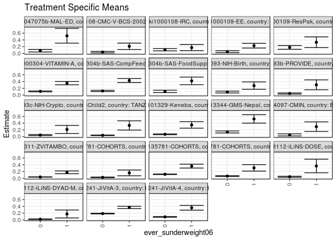

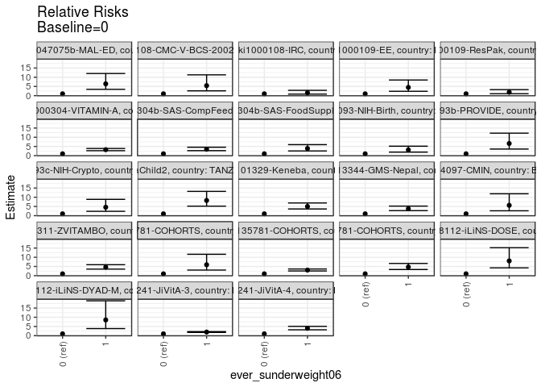

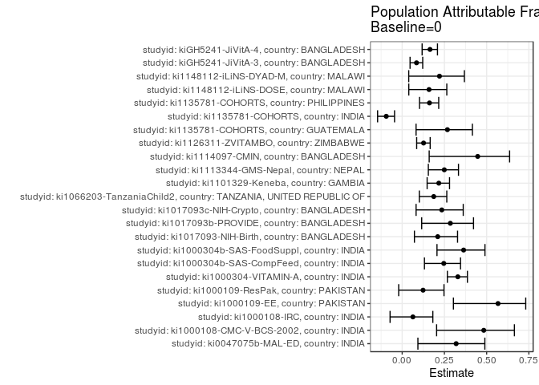

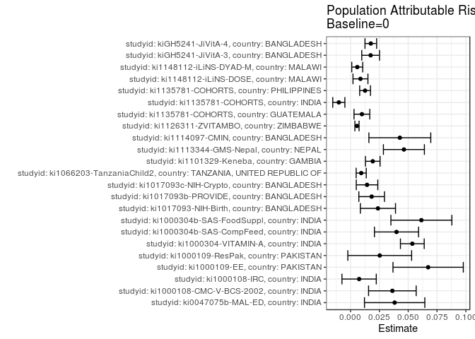

## Results Table

### Parameter: TSM

| studyid | country | intervention_level | baseline_level | estimate | ci_lower | ci_upper |
| --- | --- | --- | --- | --- | --- | --- |
| ki0047075b-MAL-ED | INDIA | 0 | NA | 0.0814230 | 0.0435512 | 0.1192949 |
| ki0047075b-MAL-ED | INDIA | 1 | NA | 0.5229483 | 0.3043385 | 0.7415580 |
| ki1000108-CMC-V-BCS-2002 | INDIA | 0 | NA | 0.0388078 | 0.0165444 | 0.0610712 |
| ki1000108-CMC-V-BCS-2002 | INDIA | 1 | NA | 0.2105053 | 0.1162015 | 0.3048091 |
| ki1000108-IRC | INDIA | 0 | NA | 0.1096480 | 0.0767658 | 0.1425301 |
| ki1000108-IRC | INDIA | 1 | NA | 0.1715943 | 0.0807986 | 0.2623899 |
| ki1000109-EE | PAKISTAN | 0 | NA | 0.0513059 | 0.0227781 | 0.0798338 |
| ki1000109-EE | PAKISTAN | 1 | NA | 0.2298610 | 0.1597531 | 0.2999689 |
| ki1000109-ResPak | PAKISTAN | 0 | NA | 0.1792550 | 0.1235130 | 0.2349970 |
| ki1000109-ResPak | PAKISTAN | 1 | NA | 0.3308195 | 0.1712863 | 0.4903526 |
| ki1000304-VITAMIN-A | INDIA | 0 | NA | 0.1090273 | 0.0954726 | 0.1225819 |
| ki1000304-VITAMIN-A | INDIA | 1 | NA | 0.3532121 | 0.3045245 | 0.4018998 |
| ki1000304b-SAS-CompFeed | INDIA | 0 | NA | 0.1220091 | 0.1030184 | 0.1409998 |
| ki1000304b-SAS-CompFeed | INDIA | 1 | NA | 0.4295957 | 0.3695822 | 0.4896092 |
| ki1000304b-SAS-FoodSuppl | INDIA | 0 | NA | 0.1074673 | 0.0720430 | 0.1428916 |
| ki1000304b-SAS-FoodSuppl | INDIA | 1 | NA | 0.4187680 | 0.3056331 | 0.5319028 |
| ki1017093-NIH-Birth | BANGLADESH | 0 | NA | 0.0890988 | 0.0626867 | 0.1155110 |
| ki1017093-NIH-Birth | BANGLADESH | 1 | NA | 0.2799265 | 0.1708905 | 0.3889625 |
| ki1017093b-PROVIDE | BANGLADESH | 0 | NA | 0.0458541 | 0.0286259 | 0.0630823 |
| ki1017093b-PROVIDE | BANGLADESH | 1 | NA | 0.3032395 | 0.1566717 | 0.4498072 |
| ki1017093c-NIH-Crypto | BANGLADESH | 0 | NA | 0.0466529 | 0.0307278 | 0.0625780 |
| ki1017093c-NIH-Crypto | BANGLADESH | 1 | NA | 0.2135294 | 0.0929965 | 0.3340623 |
| ki1066203-TanzaniaChild2 | TANZANIA, UNITED REPUBLIC OF | 0 | NA | 0.0402136 | 0.0313027 | 0.0491245 |
| ki1066203-TanzaniaChild2 | TANZANIA, UNITED REPUBLIC OF | 1 | NA | 0.3321573 | 0.1950875 | 0.4692272 |
| ki1101329-Keneba | GAMBIA | 0 | NA | 0.0695383 | 0.0583396 | 0.0807370 |
| ki1101329-Keneba | GAMBIA | 1 | NA | 0.3473945 | 0.2512680 | 0.4435209 |
| ki1113344-GMS-Nepal | NEPAL | 0 | NA | 0.1392968 | 0.1094339 | 0.1691597 |
| ki1113344-GMS-Nepal | NEPAL | 1 | NA | 0.5250211 | 0.3997360 | 0.6503061 |
| ki1114097-CMIN | BANGLADESH | 0 | NA | 0.0528764 | 0.0222592 | 0.0834935 |
| ki1114097-CMIN | BANGLADESH | 1 | NA | 0.2967312 | 0.1546365 | 0.4388259 |
| ki1126311-ZVITAMBO | ZIMBABWE | 0 | NA | 0.0383137 | 0.0341037 | 0.0425237 |
| ki1126311-ZVITAMBO | ZIMBABWE | 1 | NA | 0.1766930 | 0.1356373 | 0.2177488 |
| ki1135781-COHORTS | GUATEMALA | 0 | NA | 0.0268860 | 0.0160521 | 0.0377200 |
| ki1135781-COHORTS | GUATEMALA | 1 | NA | 0.1596770 | 0.0740817 | 0.2452723 |
| ki1135781-COHORTS | INDIA | 0 | NA | 0.1183929 | 0.1097396 | 0.1270462 |
| ki1135781-COHORTS | INDIA | 1 | NA | 0.3598915 | 0.3023619 | 0.4174212 |
| ki1135781-COHORTS | PHILIPPINES | 0 | NA | 0.0653941 | 0.0558403 | 0.0749480 |
| ki1135781-COHORTS | PHILIPPINES | 1 | NA | 0.3079374 | 0.2127450 | 0.4031299 |
| ki1148112-iLiNS-DOSE | MALAWI | 0 | NA | 0.0453401 | 0.0308600 | 0.0598201 |
| ki1148112-iLiNS-DOSE | MALAWI | 1 | NA | 0.3636364 | 0.1625006 | 0.5647722 |
| ki1148112-iLiNS-DYAD-M | MALAWI | 0 | NA | 0.0204678 | 0.0117997 | 0.0291359 |
| ki1148112-iLiNS-DYAD-M | MALAWI | 1 | NA | 0.1750000 | 0.0571939 | 0.2928061 |
| kiGH5241-JiVitA-3 | BANGLADESH | 0 | NA | 0.1877884 | 0.1774635 | 0.1981132 |
| kiGH5241-JiVitA-3 | BANGLADESH | 1 | NA | 0.3696903 | 0.3356387 | 0.4037419 |
| kiGH5241-JiVitA-4 | BANGLADESH | 0 | NA | 0.0891091 | 0.0789223 | 0.0992958 |
| kiGH5241-JiVitA-4 | BANGLADESH | 1 | NA | 0.3593071 | 0.2881240 | 0.4304902 |

### Parameter: E(Y)

| studyid | country | intervention_level | baseline_level | estimate | ci_lower | ci_upper |
| --- | --- | --- | --- | --- | --- | --- |
| ki0047075b-MAL-ED | INDIA | NA | NA | 0.1196581 | 0.0779840 | 0.1613323 |
| ki1000108-CMC-V-BCS-2002 | INDIA | NA | NA | 0.0750670 | 0.0482904 | 0.1018437 |
| ki1000108-IRC | INDIA | NA | NA | 0.1170732 | 0.0859146 | 0.1482317 |
| ki1000109-EE | PAKISTAN | NA | NA | 0.1185984 | 0.0856546 | 0.1515422 |
| ki1000109-ResPak | PAKISTAN | NA | NA | 0.2045455 | 0.1511224 | 0.2579685 |
| ki1000304-VITAMIN-A | INDIA | NA | NA | 0.1626016 | 0.1492881 | 0.1759151 |
| ki1000304b-SAS-CompFeed | INDIA | NA | NA | 0.1618625 | 0.1426768 | 0.1810483 |
| ki1000304b-SAS-FoodSuppl | INDIA | NA | NA | 0.1689008 | 0.1308276 | 0.2069740 |
| ki1017093-NIH-Birth | BANGLADESH | NA | NA | 0.1128405 | 0.0854611 | 0.1402198 |
| ki1017093b-PROVIDE | BANGLADESH | NA | NA | 0.0641447 | 0.0446535 | 0.0836359 |
| ki1017093c-NIH-Crypto | BANGLADESH | NA | NA | 0.0609418 | 0.0434802 | 0.0784034 |
| ki1066203-TanzaniaChild2 | TANZANIA, UNITED REPUBLIC OF | NA | NA | 0.0494534 | 0.0397554 | 0.0591514 |
| ki1101329-Keneba | GAMBIA | NA | NA | 0.0887872 | 0.0768581 | 0.1007163 |
| ki1113344-GMS-Nepal | NEPAL | NA | NA | 0.1855670 | 0.1539560 | 0.2171780 |
| ki1114097-CMIN | BANGLADESH | NA | NA | 0.0956175 | 0.0591654 | 0.1320697 |
| ki1126311-ZVITAMBO | ZIMBABWE | NA | NA | 0.0438689 | 0.0395328 | 0.0482049 |
| ki1135781-COHORTS | GUATEMALA | NA | NA | 0.0367171 | 0.0245975 | 0.0488367 |
| ki1135781-COHORTS | INDIA | NA | NA | 0.1082022 | 0.1003643 | 0.1160400 |
| ki1135781-COHORTS | PHILIPPINES | NA | NA | 0.0779833 | 0.0679723 | 0.0879943 |
| ki1148112-iLiNS-DOSE | MALAWI | NA | NA | 0.0539216 | 0.0384151 | 0.0694281 |
| ki1148112-iLiNS-DYAD-M | MALAWI | NA | NA | 0.0262664 | 0.0166615 | 0.0358713 |
| kiGH5241-JiVitA-3 | BANGLADESH | NA | NA | 0.2052021 | 0.1976666 | 0.2127376 |
| kiGH5241-JiVitA-4 | BANGLADESH | NA | NA | 0.1066772 | 0.0962568 | 0.1170977 |

### Parameter: RR

| studyid | country | intervention_level | baseline_level | estimate | ci_lower | ci_upper |
| --- | --- | --- | --- | --- | --- | --- |
| ki0047075b-MAL-ED | INDIA | 0 | 0 | 1.000000 | 1.0000000 | 1.000000 |
| ki0047075b-MAL-ED | INDIA | 1 | 0 | 6.422608 | 3.4326072 | 12.017073 |
| ki1000108-CMC-V-BCS-2002 | INDIA | 0 | 0 | 1.000000 | 1.0000000 | 1.000000 |
| ki1000108-CMC-V-BCS-2002 | INDIA | 1 | 0 | 5.424307 | 2.6073468 | 11.284692 |
| ki1000108-IRC | INDIA | 0 | 0 | 1.000000 | 1.0000000 | 1.000000 |
| ki1000108-IRC | INDIA | 1 | 0 | 1.564956 | 0.8512196 | 2.877150 |
| ki1000109-EE | PAKISTAN | 0 | 0 | 1.000000 | 1.0000000 | 1.000000 |
| ki1000109-EE | PAKISTAN | 1 | 0 | 4.480204 | 2.3665596 | 8.481605 |
| ki1000109-ResPak | PAKISTAN | 0 | 0 | 1.000000 | 1.0000000 | 1.000000 |
| ki1000109-ResPak | PAKISTAN | 1 | 0 | 1.845525 | 1.0423174 | 3.267681 |
| ki1000304-VITAMIN-A | INDIA | 0 | 0 | 1.000000 | 1.0000000 | 1.000000 |
| ki1000304-VITAMIN-A | INDIA | 1 | 0 | 3.239668 | 2.6909486 | 3.900278 |
| ki1000304b-SAS-CompFeed | INDIA | 0 | 0 | 1.000000 | 1.0000000 | 1.000000 |
| ki1000304b-SAS-CompFeed | INDIA | 1 | 0 | 3.521014 | 2.7069788 | 4.579843 |
| ki1000304b-SAS-FoodSuppl | INDIA | 0 | 0 | 1.000000 | 1.0000000 | 1.000000 |
| ki1000304b-SAS-FoodSuppl | INDIA | 1 | 0 | 3.896701 | 2.5417233 | 5.974008 |
| ki1017093-NIH-Birth | BANGLADESH | 0 | 0 | 1.000000 | 1.0000000 | 1.000000 |
| ki1017093-NIH-Birth | BANGLADESH | 1 | 0 | 3.141752 | 1.9226277 | 5.133915 |
| ki1017093b-PROVIDE | BANGLADESH | 0 | 0 | 1.000000 | 1.0000000 | 1.000000 |
| ki1017093b-PROVIDE | BANGLADESH | 1 | 0 | 6.613138 | 3.5834533 | 12.204315 |
| ki1017093c-NIH-Crypto | BANGLADESH | 0 | 0 | 1.000000 | 1.0000000 | 1.000000 |
| ki1017093c-NIH-Crypto | BANGLADESH | 1 | 0 | 4.576980 | 2.3650179 | 8.857753 |
| ki1066203-TanzaniaChild2 | TANZANIA, UNITED REPUBLIC OF | 0 | 0 | 1.000000 | 1.0000000 | 1.000000 |
| ki1066203-TanzaniaChild2 | TANZANIA, UNITED REPUBLIC OF | 1 | 0 | 8.259821 | 5.1694208 | 13.197736 |
| ki1101329-Keneba | GAMBIA | 0 | 0 | 1.000000 | 1.0000000 | 1.000000 |
| ki1101329-Keneba | GAMBIA | 1 | 0 | 4.995728 | 3.6287408 | 6.877673 |
| ki1113344-GMS-Nepal | NEPAL | 0 | 0 | 1.000000 | 1.0000000 | 1.000000 |
| ki1113344-GMS-Nepal | NEPAL | 1 | 0 | 3.769081 | 2.7329598 | 5.198017 |
| ki1114097-CMIN | BANGLADESH | 0 | 0 | 1.000000 | 1.0000000 | 1.000000 |
| ki1114097-CMIN | BANGLADESH | 1 | 0 | 5.611794 | 2.6479669 | 11.892983 |
| ki1126311-ZVITAMBO | ZIMBABWE | 0 | 0 | 1.000000 | 1.0000000 | 1.000000 |
| ki1126311-ZVITAMBO | ZIMBABWE | 1 | 0 | 4.611748 | 3.5669323 | 5.962608 |
| ki1135781-COHORTS | GUATEMALA | 0 | 0 | 1.000000 | 1.0000000 | 1.000000 |
| ki1135781-COHORTS | GUATEMALA | 1 | 0 | 5.939032 | 3.0391641 | 11.605855 |
| ki1135781-COHORTS | INDIA | 0 | 0 | 1.000000 | 1.0000000 | 1.000000 |
| ki1135781-COHORTS | INDIA | 1 | 0 | 3.039808 | 2.5498499 | 3.623912 |
| ki1135781-COHORTS | PHILIPPINES | 0 | 0 | 1.000000 | 1.0000000 | 1.000000 |
| ki1135781-COHORTS | PHILIPPINES | 1 | 0 | 4.708945 | 3.3452569 | 6.628539 |
| ki1148112-iLiNS-DOSE | MALAWI | 0 | 0 | 1.000000 | 1.0000000 | 1.000000 |
| ki1148112-iLiNS-DOSE | MALAWI | 1 | 0 | 8.020202 | 4.2344866 | 15.190422 |
| ki1148112-iLiNS-DYAD-M | MALAWI | 0 | 0 | 1.000000 | 1.0000000 | 1.000000 |
| ki1148112-iLiNS-DYAD-M | MALAWI | 1 | 0 | 8.550000 | 3.8598198 | 18.939355 |
| kiGH5241-JiVitA-3 | BANGLADESH | 0 | 0 | 1.000000 | 1.0000000 | 1.000000 |
| kiGH5241-JiVitA-3 | BANGLADESH | 1 | 0 | 1.968654 | 1.7668660 | 2.193487 |
| kiGH5241-JiVitA-4 | BANGLADESH | 0 | 0 | 1.000000 | 1.0000000 | 1.000000 |
| kiGH5241-JiVitA-4 | BANGLADESH | 1 | 0 | 4.032217 | 3.2032308 | 5.075743 |

### Parameter: PAR

| studyid | country | intervention_level | baseline_level | estimate | ci_lower | ci_upper |
| --- | --- | --- | --- | --- | --- | --- |
| ki0047075b-MAL-ED | INDIA | 0 | NA | 0.0382351 | 0.0120535 | 0.0644166 |
| ki1000108-CMC-V-BCS-2002 | INDIA | 0 | NA | 0.0362592 | 0.0156086 | 0.0569098 |
| ki1000108-IRC | INDIA | 0 | NA | 0.0074252 | -0.0074559 | 0.0223063 |
| ki1000109-EE | PAKISTAN | 0 | NA | 0.0672925 | 0.0367885 | 0.0977964 |
| ki1000109-ResPak | PAKISTAN | 0 | NA | 0.0252905 | -0.0023894 | 0.0529703 |
| ki1000304-VITAMIN-A | INDIA | 0 | NA | 0.0535744 | 0.0432624 | 0.0638864 |
| ki1000304b-SAS-CompFeed | INDIA | 0 | NA | 0.0398534 | 0.0207079 | 0.0589990 |
| ki1000304b-SAS-FoodSuppl | INDIA | 0 | NA | 0.0614335 | 0.0349892 | 0.0878778 |
| ki1017093-NIH-Birth | BANGLADESH | 0 | NA | 0.0237416 | 0.0084977 | 0.0389855 |
| ki1017093b-PROVIDE | BANGLADESH | 0 | NA | 0.0182906 | 0.0071831 | 0.0293981 |
| ki1017093c-NIH-Crypto | BANGLADESH | 0 | NA | 0.0142889 | 0.0049501 | 0.0236278 |
| ki1066203-TanzaniaChild2 | TANZANIA, UNITED REPUBLIC OF | 0 | NA | 0.0092398 | 0.0048639 | 0.0136157 |
| ki1101329-Keneba | GAMBIA | 0 | NA | 0.0192489 | 0.0129001 | 0.0255976 |
| ki1113344-GMS-Nepal | NEPAL | 0 | NA | 0.0462702 | 0.0284879 | 0.0640525 |
| ki1114097-CMIN | BANGLADESH | 0 | NA | 0.0427412 | 0.0159017 | 0.0695806 |
| ki1126311-ZVITAMBO | ZIMBABWE | 0 | NA | 0.0055552 | 0.0037301 | 0.0073803 |
| ki1135781-COHORTS | GUATEMALA | 0 | NA | 0.0098310 | 0.0029948 | 0.0166672 |
| ki1135781-COHORTS | INDIA | 0 | NA | -0.0101907 | -0.0154441 | -0.0049373 |
| ki1135781-COHORTS | PHILIPPINES | 0 | NA | 0.0125892 | 0.0079072 | 0.0172711 |
| ki1148112-iLiNS-DOSE | MALAWI | 0 | NA | 0.0085815 | 0.0020941 | 0.0150689 |
| ki1148112-iLiNS-DYAD-M | MALAWI | 0 | NA | 0.0057986 | 0.0010281 | 0.0105691 |
| kiGH5241-JiVitA-3 | BANGLADESH | 0 | NA | 0.0174137 | 0.0097031 | 0.0251244 |
| kiGH5241-JiVitA-4 | BANGLADESH | 0 | NA | 0.0175681 | 0.0125134 | 0.0226229 |

### Parameter: PAF

| studyid | country | intervention_level | baseline_level | estimate | ci_lower | ci_upper |
| --- | --- | --- | --- | --- | --- | --- |
| ki0047075b-MAL-ED | INDIA | 0 | NA | 0.3195360 | 0.0930862 | 0.4894430 |
| ki1000108-CMC-V-BCS-2002 | INDIA | 0 | NA | 0.4830249 | 0.2038238 | 0.6643165 |
| ki1000108-IRC | INDIA | 0 | NA | 0.0634234 | -0.0716802 | 0.1814949 |
| ki1000109-EE | PAKISTAN | 0 | NA | 0.5673977 | 0.3032585 | 0.7314000 |
| ki1000109-ResPak | PAKISTAN | 0 | NA | 0.1236423 | -0.0206367 | 0.2475257 |
| ki1000304-VITAMIN-A | INDIA | 0 | NA | 0.3294823 | 0.2675841 | 0.3861493 |
| ki1000304b-SAS-CompFeed | INDIA | 0 | NA | 0.2462178 | 0.1319050 | 0.3454775 |
| ki1000304b-SAS-FoodSuppl | INDIA | 0 | NA | 0.3637252 | 0.2060749 | 0.4900708 |
| ki1017093-NIH-Birth | BANGLADESH | 0 | NA | 0.2104000 | 0.0724881 | 0.3278057 |
| ki1017093b-PROVIDE | BANGLADESH | 0 | NA | 0.2851464 | 0.1154528 | 0.4222855 |
| ki1017093c-NIH-Crypto | BANGLADESH | 0 | NA | 0.2344684 | 0.0823477 | 0.3613717 |
| ki1066203-TanzaniaChild2 | TANZANIA, UNITED REPUBLIC OF | 0 | NA | 0.1868383 | 0.1014669 | 0.2640983 |
| ki1101329-Keneba | GAMBIA | 0 | NA | 0.2167979 | 0.1476704 | 0.2803188 |
| ki1113344-GMS-Nepal | NEPAL | 0 | NA | 0.2493448 | 0.1548657 | 0.3332619 |
| ki1114097-CMIN | BANGLADESH | 0 | NA | 0.4470015 | 0.1598920 | 0.6359904 |
| ki1126311-ZVITAMBO | ZIMBABWE | 0 | NA | 0.1266315 | 0.0857350 | 0.1656986 |
| ki1135781-COHORTS | GUATEMALA | 0 | NA | 0.2677510 | 0.0822704 | 0.4157445 |
| ki1135781-COHORTS | INDIA | 0 | NA | -0.0941822 | -0.1455268 | -0.0451389 |
| ki1135781-COHORTS | PHILIPPINES | 0 | NA | 0.1614342 | 0.1027756 | 0.2162578 |
| ki1148112-iLiNS-DOSE | MALAWI | 0 | NA | 0.1591482 | 0.0391575 | 0.2641543 |
| ki1148112-iLiNS-DYAD-M | MALAWI | 0 | NA | 0.2207602 | 0.0388032 | 0.3682724 |
| kiGH5241-JiVitA-3 | BANGLADESH | 0 | NA | 0.0848614 | 0.0466382 | 0.1215521 |
| kiGH5241-JiVitA-4 | BANGLADESH | 0 | NA | 0.1646851 | 0.1179895 | 0.2089084 |